# UW DS350 Final Project

Danny Godbout

August 22, 2016

### Summary

The [dataset](http://archive.ics.uci.edu/ml/datasets/Air+Quality) used in this project contains 9357 observations of air quality measurements from an Italian city, recorded from March 2004 to February 2005.

Following an initial exploration of the dataset, this project seeks to investigate the following questions:

1. Are CO and NOx sensor measurements reliable, with respect to gold standard measures?
2. What times of day exhibit the highest/lowest levels of CO and NOx polution? Days of the week?
3. How do levels of NOx air polution correlate with the presence of petroleum-based fuel sources?

For the first question, correlation analysis between sensor and gold standard measurements show reasonable performance (R^2 = 0.74) for CO sensors, but marginal performance for the NO sensor (R^@ = 0.62).

Reviewing daily and weekly trends in polution concentrations, bootstraps and ANOVAs show both CO and NOx are significantly lower in the early morning hours, and peak during morning and evening commute times. Sundays show the lowest polution levels, with steadily increasing levels to Thursday and Friday peaks.

Finally, strong correlation was found between NOx and Benzene (R^2 = 0.78), with temperature and humidity exacerbating NOx concentrations for a given level of Benzene.

### Initial Exploration

The [dataset](http://archive.ics.uci.edu/ml/datasets/Air+Quality) used in this project contains 9357 observations of air quality measurements from an Italian city, recorded from March 2004 to February 2005.

According to the data source, the column names are defined as:

1. Date (DD/MM/YYYY)
2. Time (HH.MM.SS)
3. True hourly averaged concentration CO in mg/m^3 (reference analyzer)
4. PT08.S1 (tin oxide) hourly averaged sensor response (nominally CO targeted)
5. True hourly averaged overall Non Metanic HydroCarbons concentration in microg/m^3 (reference analyzer)
6. True hourly averaged Benzene concentration in microg/m^3 (reference analyzer)
7. PT08.S2 (titania) hourly averaged sensor response (nominally NMHC targeted)
8. True hourly averaged NOx concentration in ppb (reference analyzer)
9. PT08.S3 (tungsten oxide) hourly averaged sensor response (nominally NOx targeted)
10. True hourly averaged NO2 concentration in microg/m^3 (reference analyzer)
11. PT08.S4 (tungsten oxide) hourly averaged sensor response (nominally NO2 targeted)
12. PT08.S5 (indium oxide) hourly averaged sensor response (nominally O3 targeted)
13. Temperature in Â°C
14. Relative Humidity (%)
15. AH Absolute Humidity
16. Concatenated Date-Time column

After importing the data, we review the summary of the dataset:

```
'data.frame':   9357 obs. of  16 variables:
 $ Date         : chr  "3/10/2004" "3/10/2004" "3/10/2004" "3/10/2004" ...
 $ Time         : chr  "18:00:00" "19:00:00" "20:00:00" "21:00:00" ...
 $ CO.GT.       : num  2.6 2 2.2 2.2 1.6 1.2 1.2 1 0.9 0.6 ...
 $ PT08.S1.CO.  : int  1360 1292 1402 1376 1272 1197 1185 1136 1094 1010 ...
 $ NMHC.GT.     : int  150 112 88 80 51 38 31 31 24 19 ...
 $ C6H6.GT.     : num  11.9 9.4 9 9.2 6.5 4.7 3.6 3.3 2.3 1.7 ...
 $ PT08.S2.NMHC.: int  1046 955 939 948 836 750 690 672 609 561 ...
 $ NOx.GT.      : int  166 103 131 172 131 89 62 62 45 NA ...
 $ PT08.S3.NOx. : int  1056 1174 1140 1092 1205 1337 1462 1453 1579 1705 ...
 $ NO2.GT.      : int  113 92 114 122 116 96 77 76 60 NA ...
 $ PT08.S4.NO2. : int  1692 1559 1555 1584 1490 1393 1333 1333 1276 1235 ...
 $ PT08.S5.O3.  : int  1268 972 1074 1203 1110 949 733 730 620 501 ...
 $ T            : num  13.6 13.3 11.9 11 11.2 11.2 11.3 10.7 10.7 10.3 ...
 $ RH           : num  48.9 47.7 54 60 59.6 59.2 56.8 60 59.7 60.2 ...
 $ AH           : num  0.758 0.726 0.75 0.787 0.789 ...
 $ timestamp    : POSIXct, format: "2004-03-10 18:00:00" "2004-03-10 19:00:00" ...
```

Furthermore, a brief review of the pair plot appears to show correlation between many variables. This is not very surprising, as it is reasonable to assume many forms of air polution might share sources like vehicle or building exhaust.

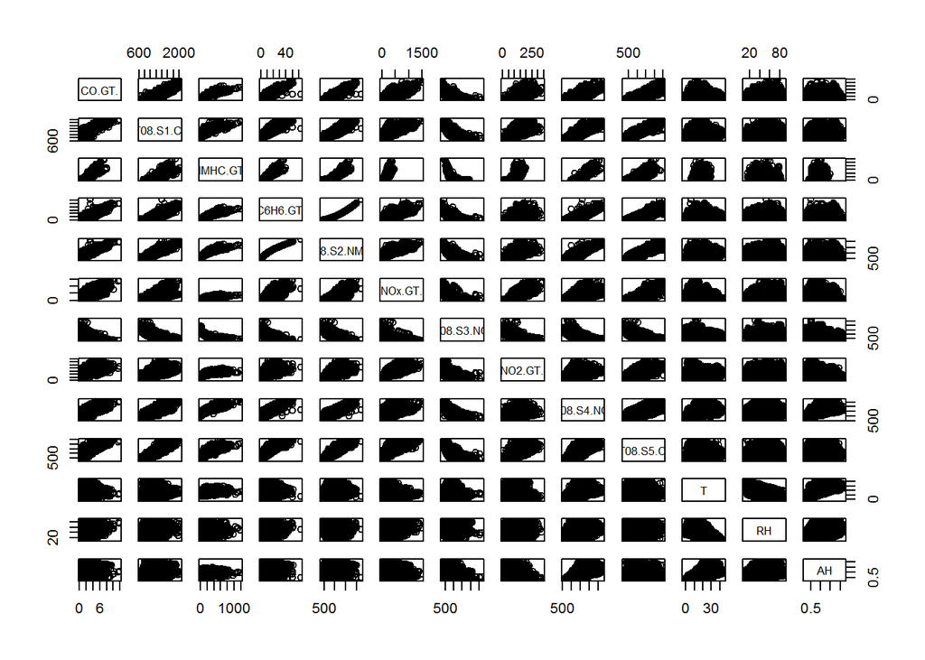

Focusing specifically on CO and NOx measurements, the variable normality plots reveal deviations from normality in both sensor and gold standard records for both pollutants. *Log transformations of all measures will be used for analysis.*

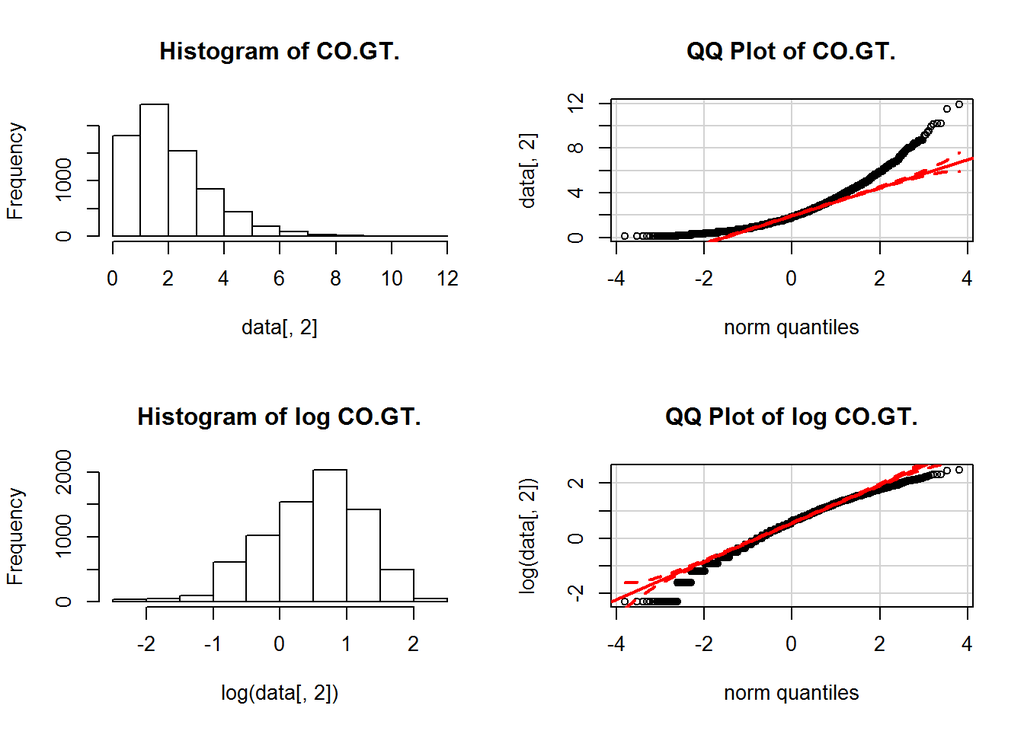

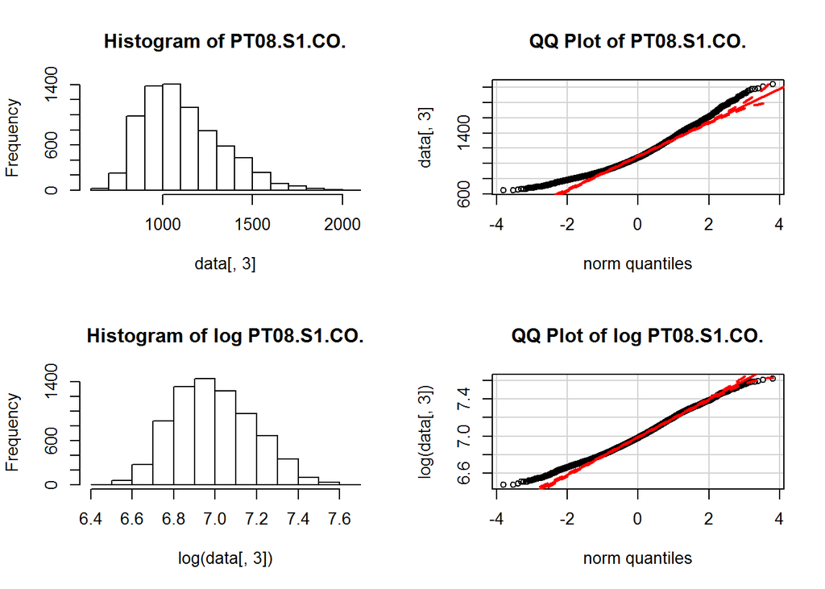

```
[1] "Shapiro-Wilk test of CO.GT."
```

```
    Shapiro-Wilk normality test

data:  data
W = 0.89799, p-value < 2.2e-16


    Shapiro-Wilk normality test

data:  log(data)
W = 0.98141, p-value < 2.2e-16
```

```
[1] "Shapiro-Wilk test of PT08.S1.CO."
```

```
    Shapiro-Wilk normality test

data:  data
W = 0.96336, p-value < 2.2e-16


    Shapiro-Wilk normality test

data:  log(data)
W = 0.99119, p-value < 2.2e-16
```

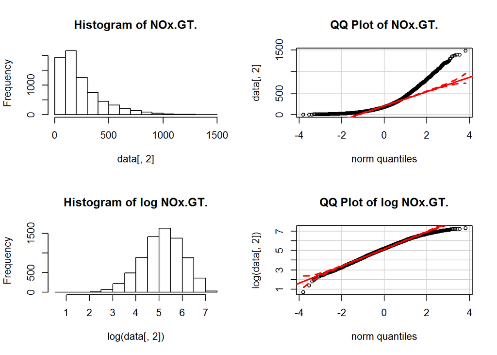

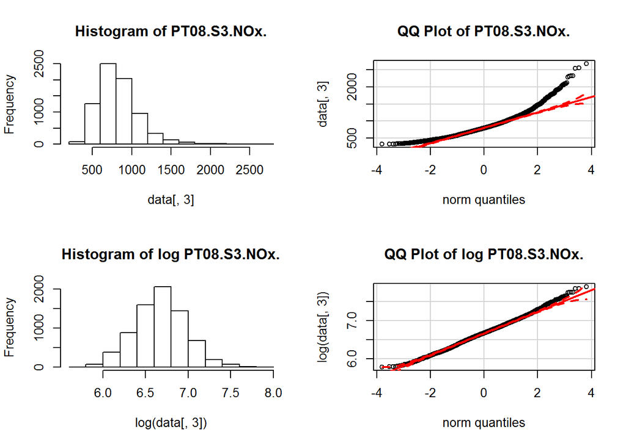

```
[1] "Shapiro-Wilk test of NOx.GT."
```

```
    Shapiro-Wilk normality test

data:  data
W = 0.83845, p-value < 2.2e-16


    Shapiro-Wilk normality test

data:  log(data)
W = 0.99219, p-value = 5.739e-16
```

```
[1] "Shapiro-Wilk test of PT08.S3.NOx."
```

```
    Shapiro-Wilk normality test

data:  data
W = 0.93485, p-value < 2.2e-16


    Shapiro-Wilk normality test

data:  log(data)
W = 0.99782, p-value = 1.572e-06
```

### Project Questions

From the initial investigation, a few observations focus the scope of this project:

- Variables including PT08 and GT in their names represent field sensor and gold standard measurements, respectively, of same variables.
- CO and NOx are commonly discussed air pollution variables and will be the focus of this project.
- One column, C6H6.GT., measures benzene concentration, which ostensibly indicates vehicular traffic.

These observations generate the following questions for investigation:

1. Are sensor measurements reliable, with respect to gold standard measures?
2. What times of day exhibit the highest/lowest levels of polution? Days of the week?
3. How do levels of NOx and CO air polution correlate with the presence of petroleum-based fuel sources?

### 1 Sensor Performance

We use a linear model to evaluate the ability to predict the gold standard value of a polution level from the sensor reading.

Final iterations of the linear models for each pollutant (CO and NOx) show a reasonable R-squared of 0.74 for CO, providing good directional measurements. Meanwhile the NOx sensor only achieved an R-squared of 0.62, perhaps a bit weak.

#### CO Sensor Performance

Fitting a linear model to predict gold standard CO measurements from CO sensor data produces the following model with a reasonable R-squared of 0.7174. The diagnostic plots show extensive deviation of residuals from normality and multiple points with high residual-leverage. * Note that the model uses log transforms of both sensor and gold standard measures *

```
Call:
lm(formula = log.CO.GT. ~ log.PT08.S1.CO., data = CO.data)

Residuals:
     Min       1Q   Median       3Q      Max
-2.92979 -0.18404  0.02821  0.23028  2.03143

Coefficients:
                 Estimate Std. Error t value Pr(>|t|)
(Intercept)     -22.19044    0.16641  -133.3   <2e-16 ***
log.PT08.S1.CO.   3.24699    0.02378   136.5   <2e-16 ***
---
Signif. codes:  0 '***' 0.001 '**' 0.01 '*' 0.05 '.' 0.1 ' ' 1

Residual standard error: 0.3895 on 7342 degrees of freedom
Multiple R-squared:  0.7174,    Adjusted R-squared:  0.7174
F-statistic: 1.864e+04 on 1 and 7342 DF,  p-value: < 2.2e-16
```

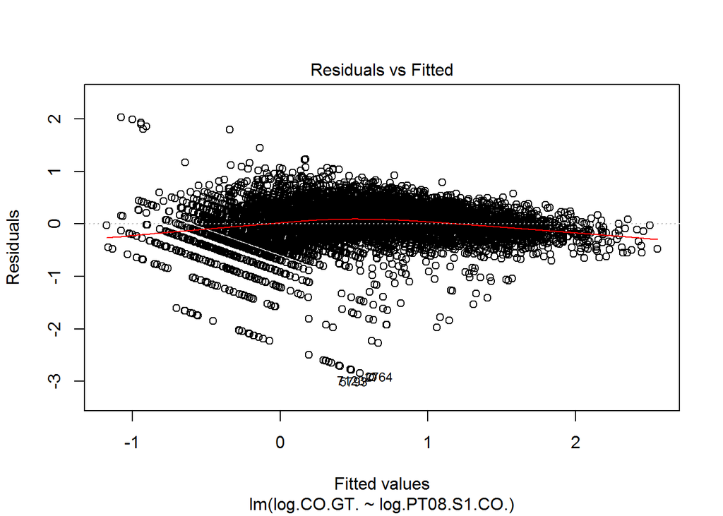

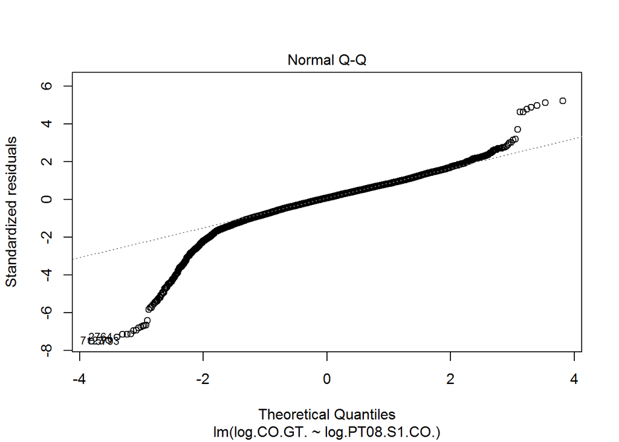

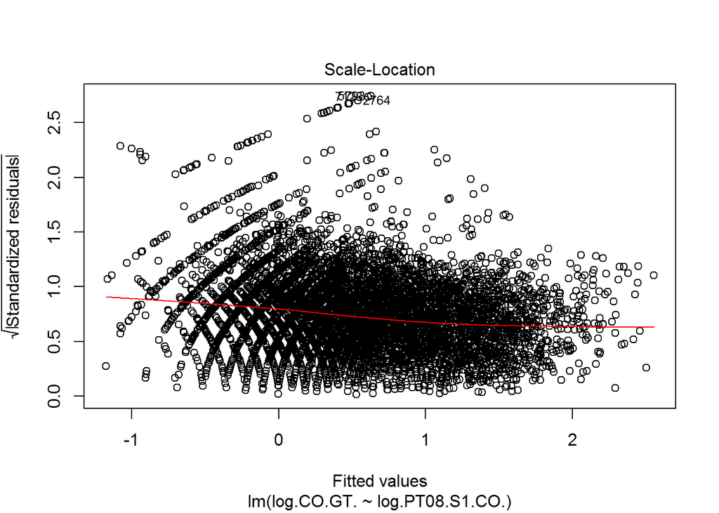

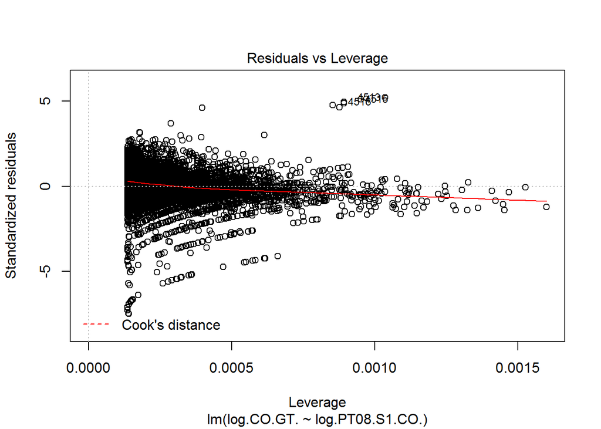

To fine-tune the model, points identified in the diagnostic plots are removed and the model is re-compiled. R-squared improves to 0.7426.

```
Call:
lm(formula = log.CO.GT. ~ log.PT08.S1.CO., data = CO.data.no.outliers)

Residuals:
    Min      1Q  Median      3Q     Max
-2.2784 -0.1857  0.0239  0.2256  1.7974

Coefficients:
                 Estimate Std. Error t value Pr(>|t|)
(Intercept)     -22.29075    0.15705  -141.9   <2e-16 ***
log.PT08.S1.CO.   3.26189    0.02244   145.3   <2e-16 ***
---
Signif. codes:  0 '***' 0.001 '**' 0.01 '*' 0.05 '.' 0.1 ' ' 1

Residual standard error: 0.3666 on 7321 degrees of freedom
Multiple R-squared:  0.7426,    Adjusted R-squared:  0.7426
F-statistic: 2.112e+04 on 1 and 7321 DF,  p-value: < 2.2e-16
```

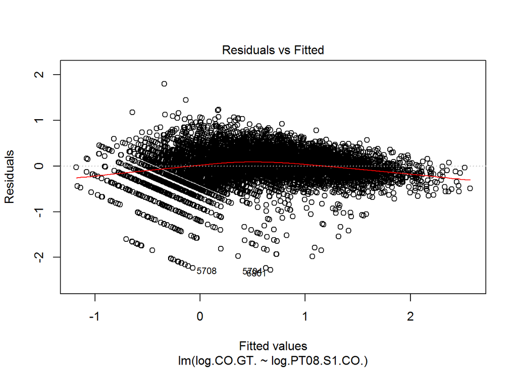

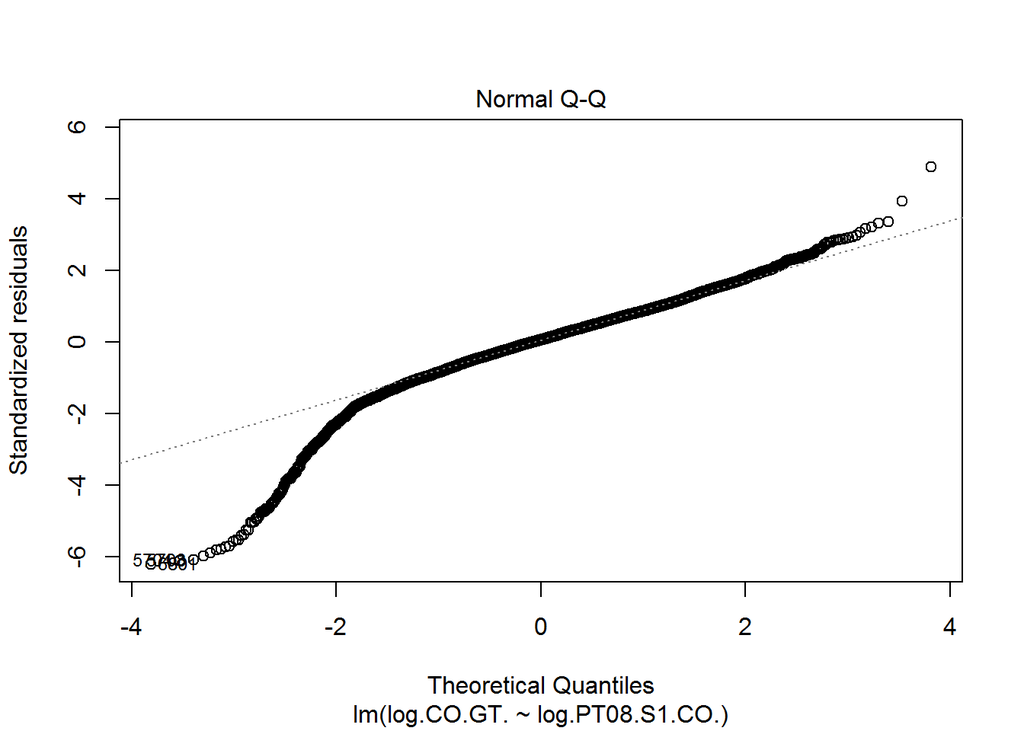

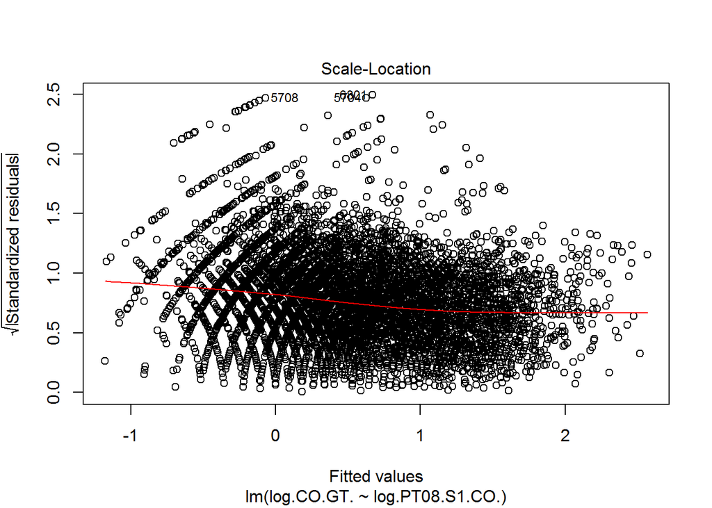

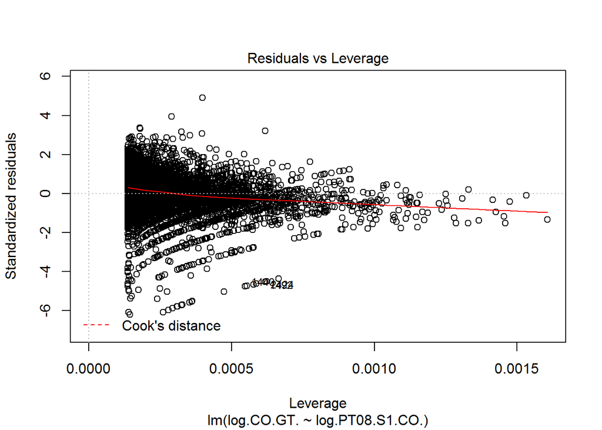

Finally, we overlay the prediction of CO.GT. from the PT08 sensor measurement with 95% confidence intervals on actual measurements from CO.GT. for visual inspection.

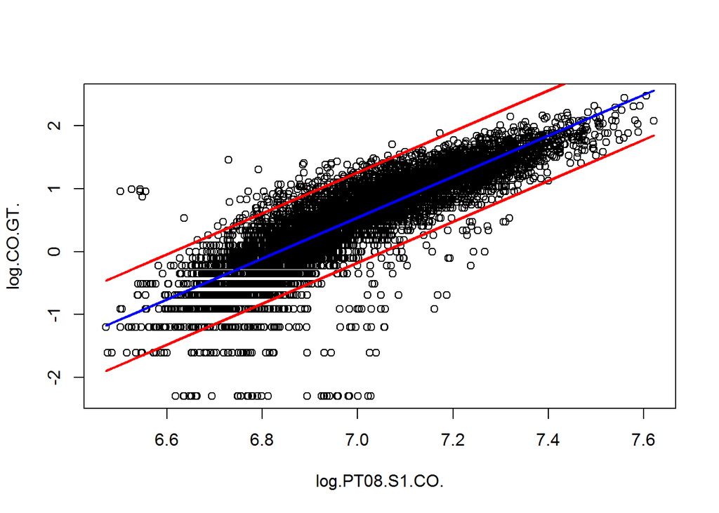

#### NOx Sensor Performance

The NOx gold standard was similarly modeled by the PT08 NOx sensor measurement. The initial model returns an R-squared of 0.6153, with similar outliers evident in the diagnostic plots.

Again, log-transforms of both variables are used. Interestingly, there is a negative correlation between the sensor and gold standard measurements, but this is not necesarilly problematic.

```
Call:
lm(formula = log.NOx.GT. ~ log.PT08.S3.NOx., data = NOx.data)

Residuals:
    Min      1Q  Median      3Q     Max
-3.4728 -0.3071  0.0289  0.3442  3.3791

Coefficients:
                 Estimate Std. Error t value Pr(>|t|)
(Intercept)       20.5157     0.1415   145.0   <2e-16 ***
log.PT08.S3.NOx.  -2.3052     0.0212  -108.8   <2e-16 ***
---
Signif. codes:  0 '***' 0.001 '**' 0.01 '*' 0.05 '.' 0.1 ' ' 1

Residual standard error: 0.5454 on 7394 degrees of freedom
Multiple R-squared:  0.6153,    Adjusted R-squared:  0.6153
F-statistic: 1.183e+04 on 1 and 7394 DF,  p-value: < 2.2e-16
```

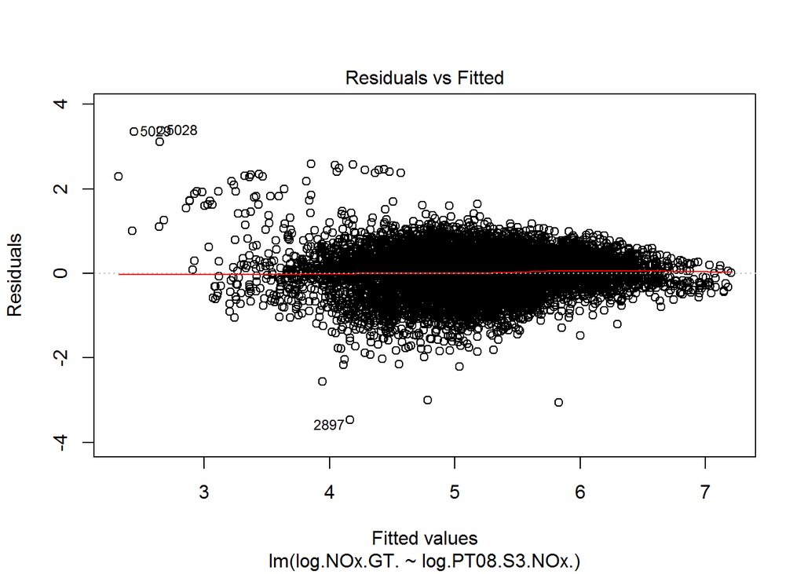

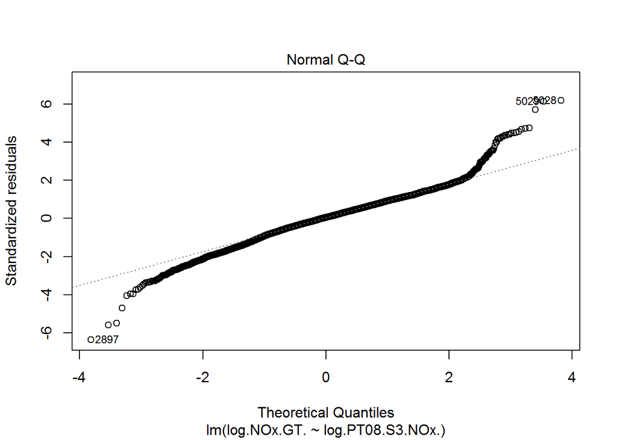

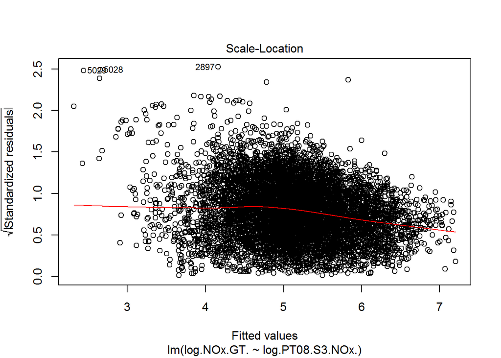

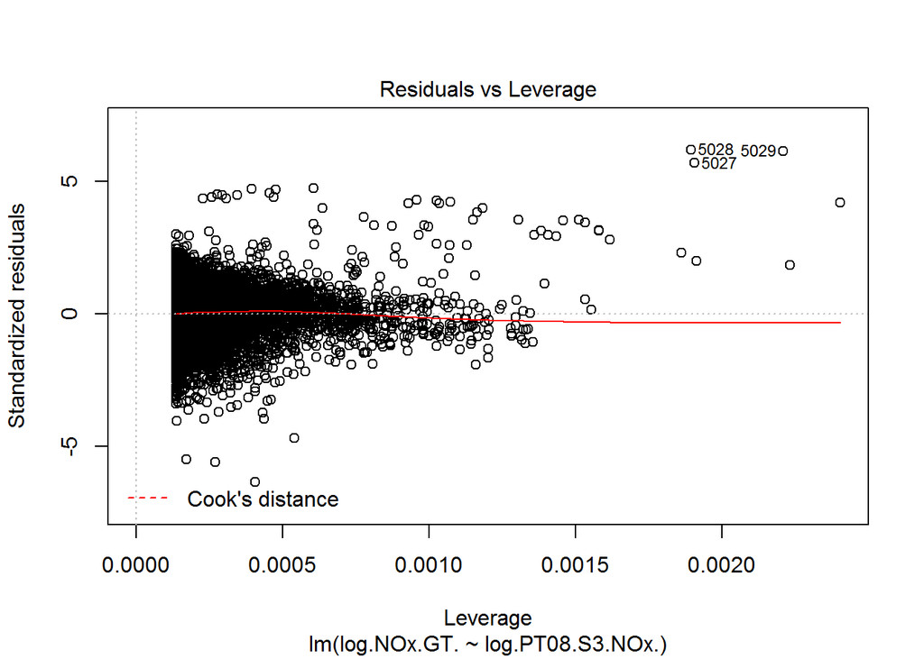

After removing outliers, R-squared improves to 0.6247- not quite as good a match as the CO sensor.

```
Call:
lm(formula = log.NOx.GT. ~ log.PT08.S3.NOx., data = NOx.data.no.outliers)

Residuals:
     Min       1Q   Median       3Q      Max
-2.55002 -0.30683  0.02828  0.34292  2.59912

Coefficients:
                 Estimate Std. Error t value Pr(>|t|)
(Intercept)      20.64453    0.13994   147.5   <2e-16 ***
log.PT08.S3.NOx. -2.32457    0.02096  -110.9   <2e-16 ***
---
Signif. codes:  0 '***' 0.001 '**' 0.01 '*' 0.05 '.' 0.1 ' ' 1

Residual standard error: 0.5371 on 7387 degrees of freedom
Multiple R-squared:  0.6247,    Adjusted R-squared:  0.6247
F-statistic: 1.23e+04 on 1 and 7387 DF,  p-value: < 2.2e-16
```

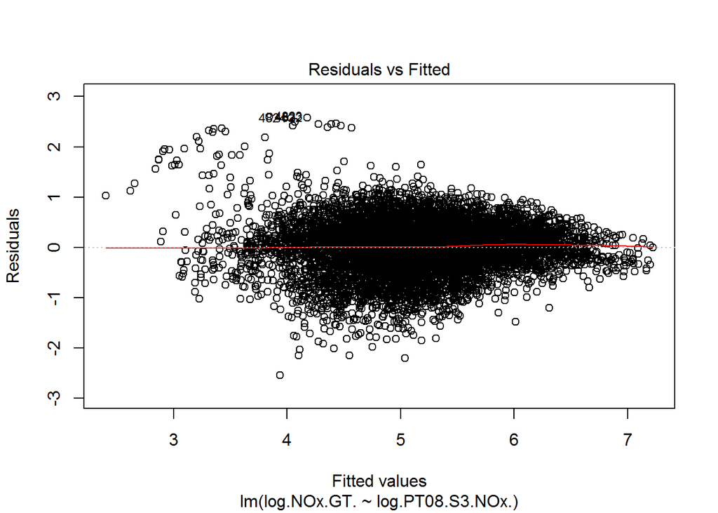

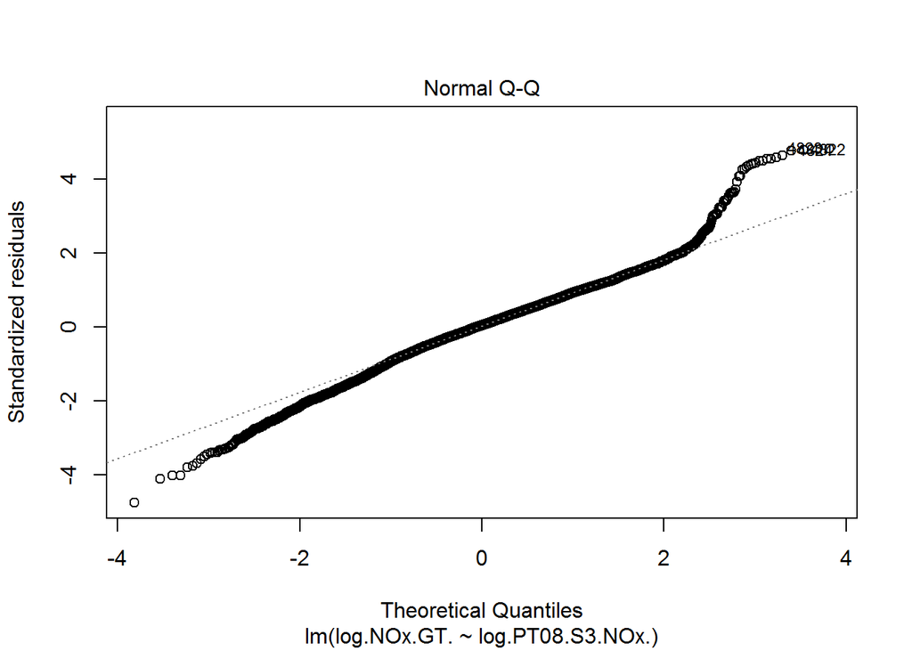

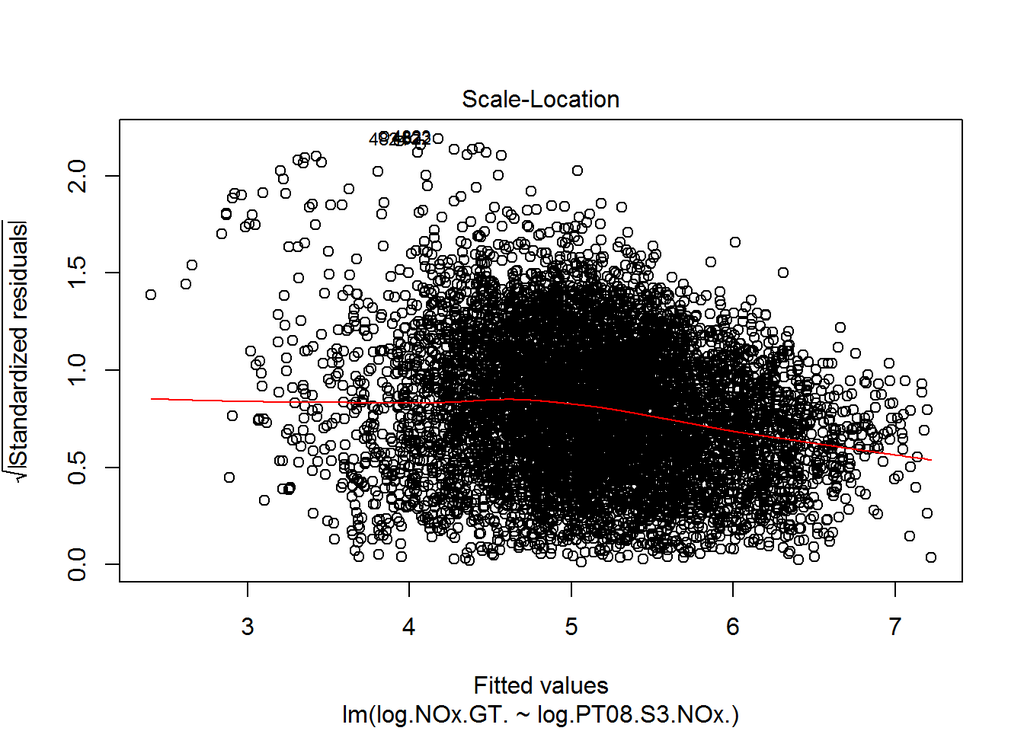

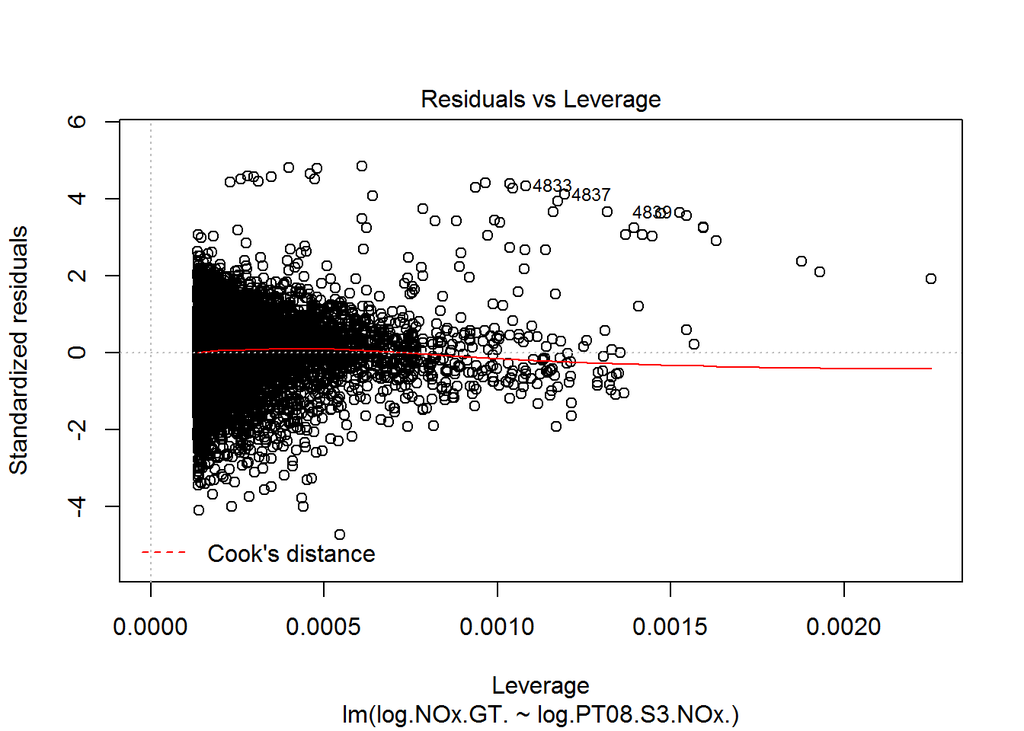

Finally, plotting the prediction of the linear model with 95% confidence intervals against actual NOx.GT. measures produces the following image.

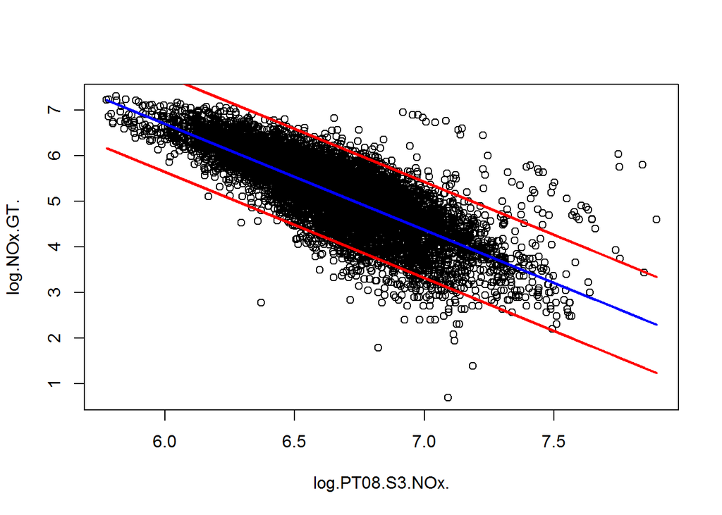

### 2 Periodic Means

To answer the hypothetical questions of “what is the best time of day to breathe?” or “what day of the week has the cleanest air?”, we review the concentrations of CO and NOx over the course of a day and week.

This section compares the hourly and daily means of CO and NOx through bootstrap and ANOVA analyses. Both pollutants show similar trends in hourly and daily profiles:

- Hourly polution is lowest in the early morning hours (2-5AM) and peaks for rush-hour commute times (8-9AM and 6-8PM).
- Daily polution is lowest on Sunday, building up to peak on Fridays.

5AM on Sunday is a good time to be outside in Italy.

#### CO Daily Concentration

In order to evaluate the relative concentration of CO over the course of a day, the daily mean CO level was subtracted from hourly measurements. The adjusted values for all hourly measures are plotted below. Points are heat-mapped by month (June is red/ New year is blue) to visually inspect seasonal trends in the daily profile. The loess smoothed mean initially indicates a low-point in CO at approximately 4AM, and peaks near rush hour times of 8AM and 6-7PM.

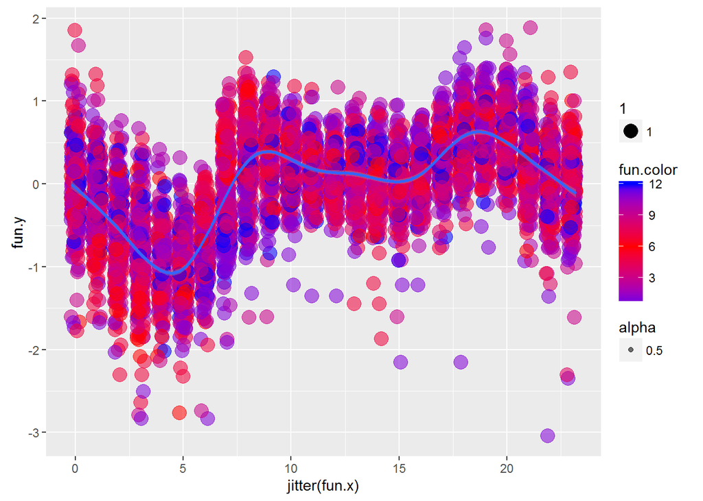

To further discern between hourly means, we bootstrap the means for each hour. The bootstrap confirms the early morning hours (2-5AM) are significantly lower. The 6-8PM timespan, conversely, shows the highest rates of pollution, with the 8-9AM morning commute closely following.

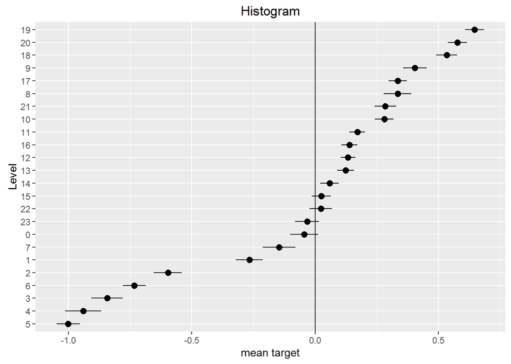

Comparing bootstrap results to the Tukey HSD ANOVA, we similarly see the largest differences between the rush hour times and the early morning hours (See 19-5).

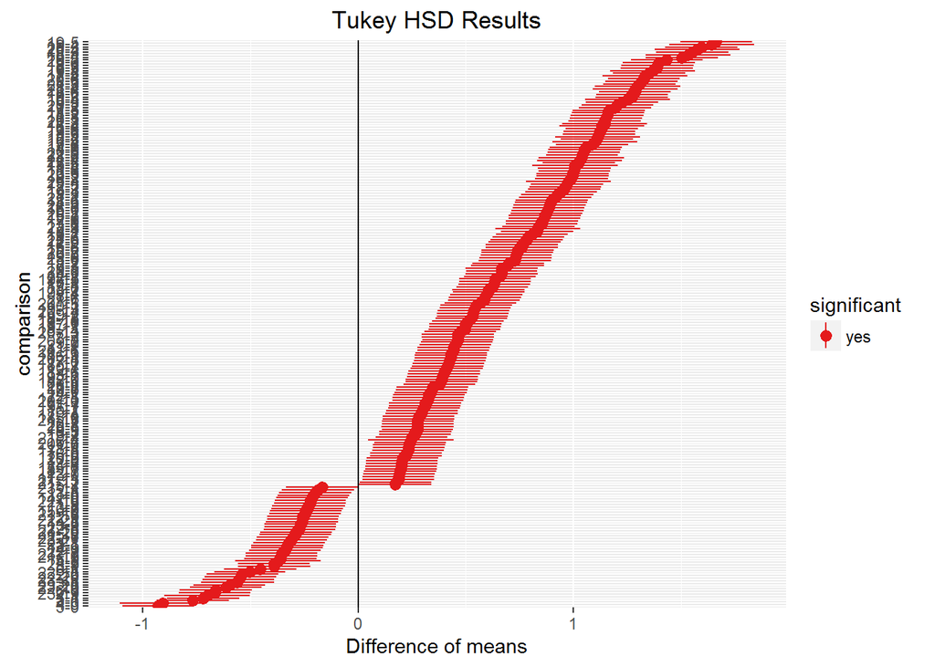

#### CO Weekly Concrentration

Plotting daily CO concentrations over the course of a week produces the follow plot, appearing to show lower concentrations on Sunday (1), increasing steadily over the workweek to a peak on Thursday/Friday (5/6), before beginning to decline on Saturday (7).

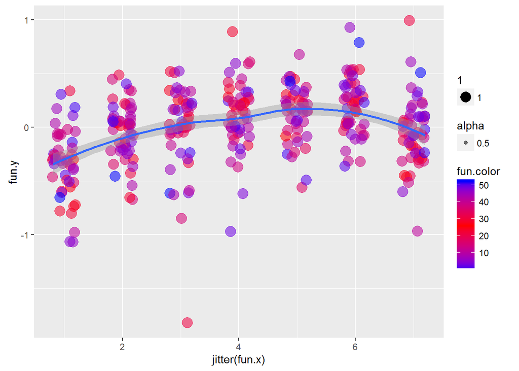

Daily bootstrapped means confirm Friday (6) CO concentrations, in particular, significantly exceed Sunday-Tuesday and Saturday levels. Sunday (1) stands out for being significantly lower than any other day of the week.

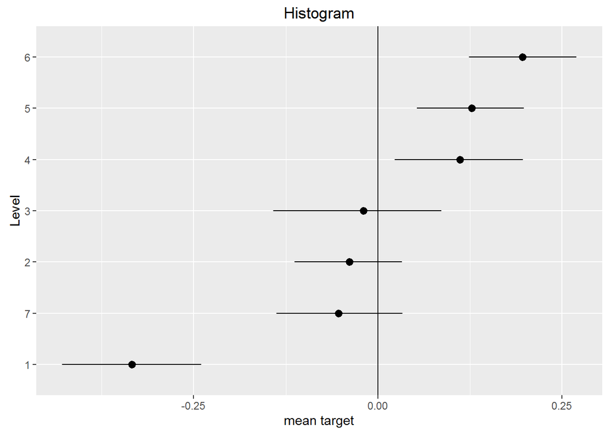

Comparing bootstrap results to the Tukey HSD ANOVA, we see the largest differences between Sunday (1) and the later-end of the work week (3-6), similar to observations of the bootstrap.

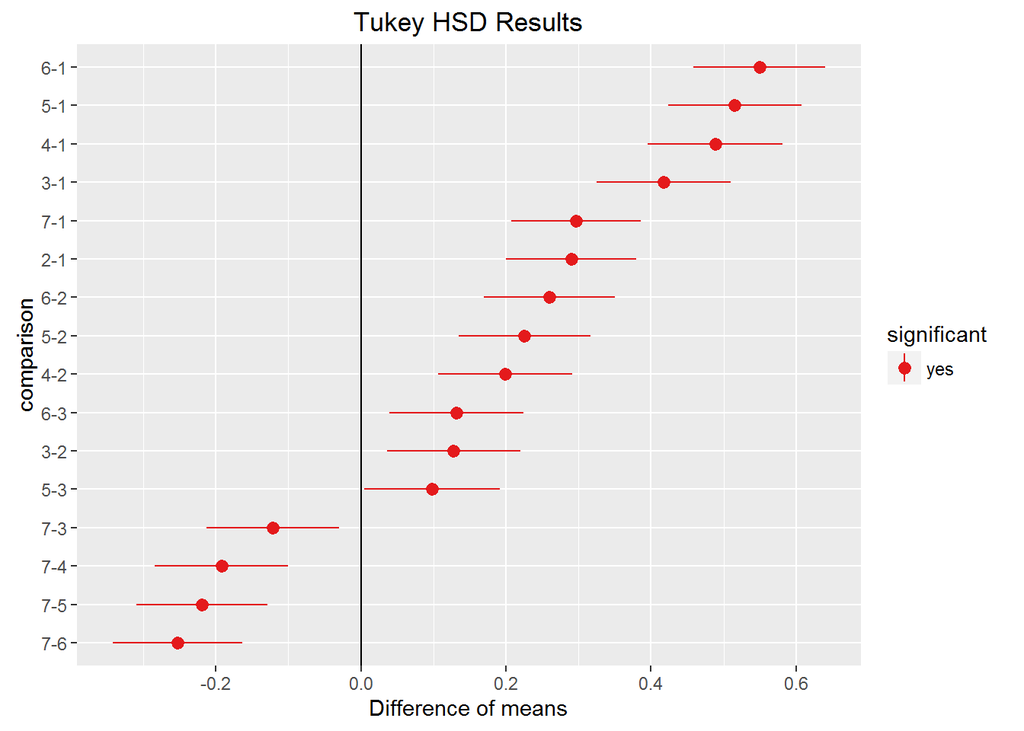

#### NOx Daily Concentration

NOx hourly concentrations follow a very similar profile to the CO hourly plot.

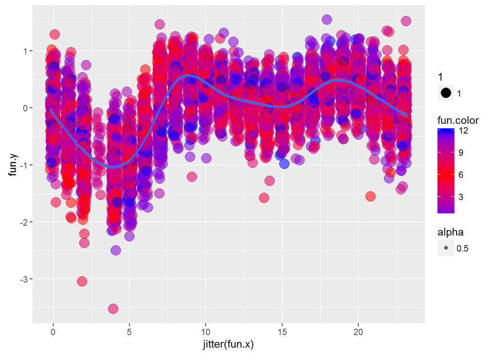

Examination of the bootstrapped NOx means reveals lows also occuring from 2-5AM. Interestingly, NOx concentrations appear equally high in the morning and evening commutes, while CO concentrations we slightly lower during the morning commute (though still high).

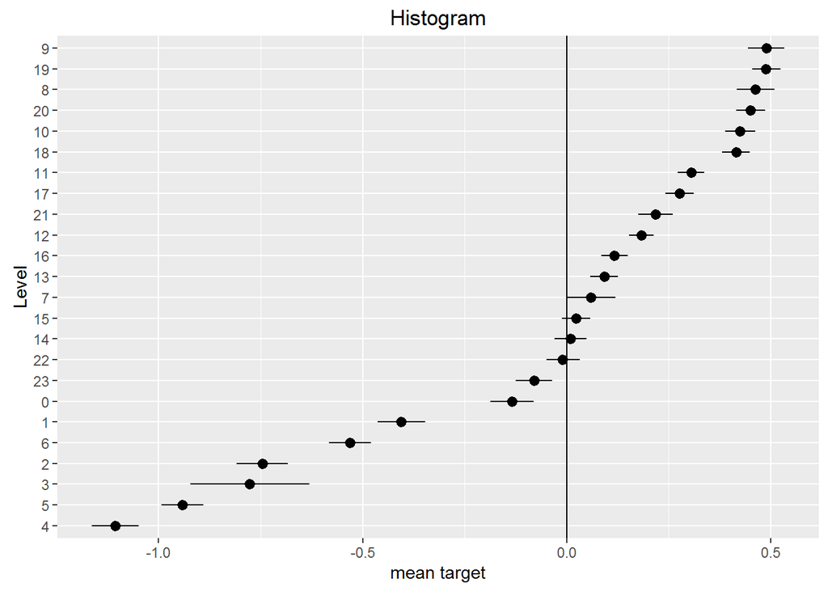

Again, the trends seen in the bootstrap are corroborated by ANOVA.

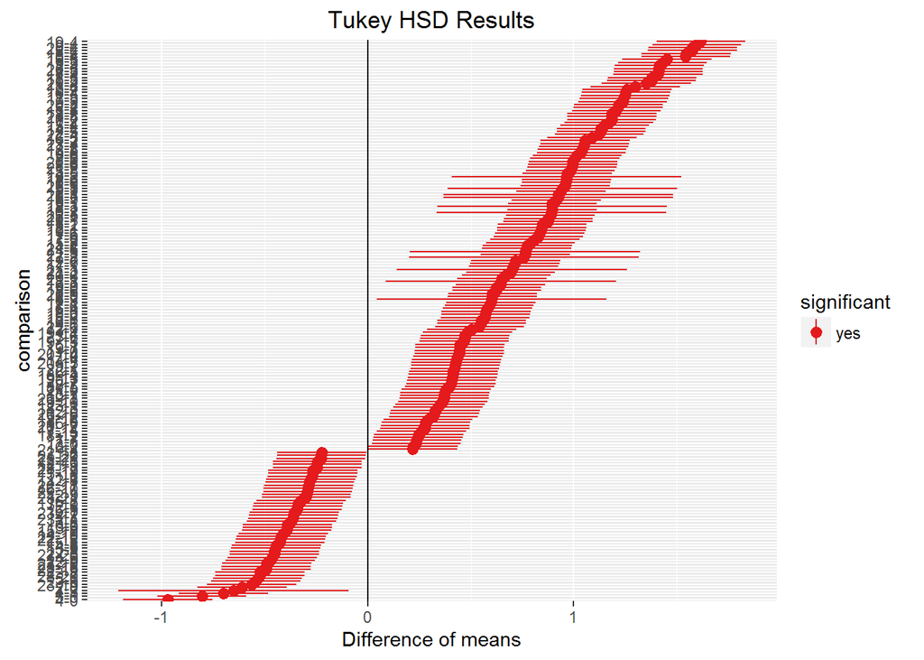